# EEG Based Classification Methodologies for Autism Spectrum Disorder

# Introduction

**Autism spectrum disorder (ASD)** is a type of neurodevelopmental disorder with core impairments in the social relationships, communication, imagination, or flexibility of thought and restricted repertoire of activity and interest. Despite so much research being conducted, the exact reason as to why this disorder occurs remain unanswered. Due to the increased cases in children diagnosed with ASD, there is need for further research on this population.At present, clinical diagnosis is mainly based on behavioral scale tests and Childhood Autism Rating Scale. Evaluation results may not be very accurate due to certain limitations.

In this study, an effective autism diagnostic system using **electroencephalogram (EEG) signals**, which are generated from electrical activity in the brain, provide critical information. EEG recordings have several advantages such as high temporal resolution, simplicity, lower costs and wider availability and are shown to be a powerful tool for the study of complex neuropyschiatric disorders.

**Research Objective** - To classify autistic subjects from normal individuals using machine learning supervised classification methodologies.

**Data Description** - The resting state eeg data used in this study is collected from Healthy Brain Network(HBN) biobank. The dataset used in this study consists of eeg recordings of 100 autistic subjects and 88 Normal subjects within the same age group between 5-19 years old and 82.8% of the subjects were male and 17.2% were female. The eeg was recorded with HydroCel Geodesic Sensor Net with 128 electrodes + Cz at a sampling rate of 500Hz.

**Data Preprocessing** :

- Data preprocessing was performed using mne and braindecode libraries.
- The Original EEG data were re-referenced with average signal from left and right mastoid sensors as they recorded less signal from the brain.
- Band-pass filters were applied to restrict the signal to a frequency range of interest between 1-40 Hz
- To improve computing speed, EEG data were down-sampled to 250 Hz
- Eyes closed part of the EEG signal were extracted as we focused on analysis with resting state EEG
- Data was segmented into 20s trails
- Voltage readings were converted into millivolts for numerical stability
- Exponential running standardisation was performed to get the standardised data
- Data obtained is of the shape (n_trails *n_channels* n_timesteps)

**Feature Engineering** :

- Power Spectrum Analysis was perfomed on the segmented trails. The relative power was calculated among the frequency bands :
  - delta (0-4 Hz)
  - theta (4-8 Hz)
  - alpha (8-12 Hz)
  - beta (13-30 Hz)
- Relative power is the ratio of each frequency's band power to the total power. The purpose of calculating the relative power is to explore abnormalities in the fluctations of autistic EEG compared with normal.
- Extracted features were stored in dataframe with 440 features (110 channels * 4 features)

**Feature Selection using PCA** :

**Machine Learning Models** :

```python
# Import requried libraries
import pandas as pd
import numpy as np
import matplotlib.pyplot as plt
import seaborn as sns

import warnings
warnings.filterwarnings('ignore')
from sklearn.decomposition import PCA
from sklearn.model_selection import train_test_split
from sklearn.metrics import plot_confusion_matrix


%matplotlib inline
sns.set(style="whitegrid")


from Auxiliar import OFHandlers as OFH
```

# Explore Phenotypic Information of dataset

```python
#read diagnosis csv containing the information about the disorders associated with each subject
df = pd.read_csv("D:/patients_diagnosis.csv")

#ajust Identifiers col, to get only the actual identifier.
df["Identifiers"]=df["Identifiers"].str.replace(",assessment","").str.strip()

#ajust the nane of the columns
col_names=df.columns
replace_dict={each:each.split(",")[1] for each in col_names if len(each.split(","))>1}
df.rename(columns=replace_dict,inplace=True)

#set the Identifiers as index
df.set_index("Identifiers",inplace=True)

# #check everything is ok
df.head(3)
```

| Identifiers | Administration | Comment_ID | DX_01 | DX_01_ByHx | DX_01_Cat | DX_01_Code | DX_01_Confirmed | DX_01_New | DX_01_PRem | DX_01_Past_Doc | ... | SWAN_17 | SWAN_18 | SWAN_HY | SWAN_IN | SWAN_Total | Season | Site | Study | Visit_label | Year |
| --- | --- | --- | --- | --- | --- | --- | --- | --- | --- | --- | --- | --- | --- | --- | --- | --- | --- | --- | --- | --- | --- |
|  | . | . | . | . | . | . | . | . | . | . | ... | NaN | NaN | NaN | NaN | NaN | NaN | NaN | NaN | NaN | NaN |
| NDARAA075AMK | All | NaN | No Diagnosis Given | 0 | No Diagnosis Given | No Diagnosis Given | NaN | 0 | 0 | NaN | ... | -2 | -1 | -2.444444 | -2.111111 | -2.277777 | Summer | 2 | HBN | NaN | 2016 |
| NDARAA117NEJ | All | NaN | ADHD-Combined Type | 0 | Neurodevelopmental Disorders | F90.2 | NaN | 1 | 0 | NaN | ... | 1 | 1 | 0.555555 | -1.111111 | -0.277777 | Winter | 1 | HBN | NaN | 2017 |

3 rows × 197 columns

```python
# check columns
df.columns
```

```
Index(['Administration', 'Comment_ID', 'DX_01', 'DX_01_ByHx', 'DX_01_Cat',
       'DX_01_Code', 'DX_01_Confirmed', 'DX_01_New', 'DX_01_PRem',
       'DX_01_Past_Doc',
       ...
       'SWAN_17', 'SWAN_18', 'SWAN_HY', 'SWAN_IN', 'SWAN_Total', 'Season',
       'Site', 'Study', 'Visit_label', 'Year'],
      dtype='object', length=197)
```

```python
#read physical csv containing the physical information of each of the subjects
physical=pd.read_csv("D:/patients_physical.csv")

#ajust Identifiers col, to get only the actual identifier.
physical["Identifiers"]=physical["Identifiers"].str.replace(",assessment","").str.strip()

#ajust the nane of the columns
col_names=physical.columns
replace_dict={each:each.split(",")[1] for each in col_names if len(each.split(","))>1}
physical.rename(columns=replace_dict,inplace=True)

#set the indentifier as index
physical.set_index("Identifiers",inplace=True)

#check everything is ok
physical.head(3)
```

| Identifiers | Administration | Age | BMI | BMI_Range | Comment_ID | Data_entry | Days_Baseline | Diastolic_BP | EID | HeartRate | ... | START_DATE | Season | Sex | Site | Study | Systolic_BP | Visit_label | Waist_Circumference | Weight | Year |
| --- | --- | --- | --- | --- | --- | --- | --- | --- | --- | --- | --- | --- | --- | --- | --- | --- | --- | --- | --- | --- | --- |
| NDARAA075AMK | All | 6.728040 | 14.858469 | Healthy Weight | NaN | Complete | 0 | 101.0 | NDARAA075AMK | 60.0 | ... | 1901-01-01T07:00:00Z | Summer | F | 2 | HBN | 127.0 | NaN | 21.0 | 42.8 | 2016 |
| NDARAA112DMH | All | 5.545744 | 15.412484 | Healthy Weight | NaN | Complete | 0 | 64.0 | NDARAA112DMH | 101.0 | ... | 1901-01-01T07:00:00Z | Fall | M | 1 | HBN | 108.0 | NaN | 19.0 | 39.6 | 2016 |
| NDARAA117NEJ | All | 7.475929 | 17.205673 | Healthy Weight | NaN | Complete | 0 | 71.0 | NDARAA117NEJ | 80.0 | ... | 1901-01-01T07:00:00Z | Fall | M | 1 | HBN | 107.0 | NaN | 24.0 | 61.8 | 2016 |

3 rows × 22 columns

```python
# Check columns
physical.columns
```

```
Index(['Administration', 'Age', 'BMI', 'BMI_Range', 'Comment_ID', 'Data_entry',
       'Days_Baseline', 'Diastolic_BP', 'EID', 'HeartRate', 'Height', 'PSCID',
       'START_DATE', 'Season', 'Sex', 'Site', 'Study', 'Systolic_BP',
       'Visit_label', 'Waist_Circumference', 'Weight', 'Year'],
      dtype='object')
```

```python
# Select required columns
select_dignosis_cols=["DX_01","DX_02","DX_03","DX_04","DX_05","DX_06","DX_07","DX_08","DX_09","DX_10"]

# Join both physical and diagnosis information to get complete phenotypic details of the each of the subjects
subjects=df[select_dignosis_cols].join(physical)

subjects.describe()
```

|  | Age | BMI | Comment_ID | Days_Baseline | Diastolic_BP | HeartRate | Height | PSCID | Site | Systolic_BP | Visit_label | Waist_Circumference | Weight | Year |
| --- | --- | --- | --- | --- | --- | --- | --- | --- | --- | --- | --- | --- | --- | --- |
| count | 2812.000000 | 2600.000000 | 0.0 | 2812.000000 | 2536.000000 | 2551.000000 | 2606.000000 | 0.0 | 2812.000000 | 2536.000000 | 0.0 | 1088.000000 | 2604.000000 | 2812.000000 |
| mean | 10.482501 | 19.524899 | NaN | 57.208037 | 67.899448 | 80.975696 | 55.860687 | NaN | 1.756046 | 114.645899 | NaN | 27.209559 | 91.313287 | 2017.394026 |
| std | 3.609182 | 5.094708 | NaN | 79.510668 | 12.097490 | 13.464703 | 7.650042 | NaN | 0.967388 | 14.329072 | NaN | 5.518408 | 44.010263 | 1.088313 |
| min | 5.003878 | 9.693766 | NaN | 0.000000 | 14.000000 | 46.000000 | 33.000000 | NaN | 1.000000 | 60.000000 | NaN | 18.000000 | 0.000000 | 2015.000000 |
| 25% | 7.615188 | 15.969742 | NaN | 0.000000 | 60.000000 | 72.000000 | 50.000000 | NaN | 1.000000 | 106.000000 | NaN | 23.000000 | 57.950000 | 2017.000000 |
| 50% | 9.826032 | 18.208080 | NaN | 41.000000 | 67.000000 | 81.000000 | 55.000000 | NaN | 1.000000 | 113.000000 | NaN | 26.000000 | 79.200000 | 2018.000000 |
| 75% | 12.886863 | 21.783796 | NaN | 80.000000 | 73.000000 | 89.000000 | 62.000000 | NaN | 3.000000 | 122.000000 | NaN | 30.000000 | 115.450000 | 2018.000000 |
| max | 21.816563 | 59.132048 | NaN | 733.000000 | 145.000000 | 139.000000 | 78.500000 | NaN | 4.000000 | 203.000000 | NaN | 51.000000 | 315.000000 | 2019.000000 |

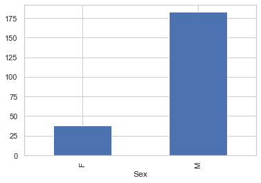

```python
# Select subjects which are below 20 years old
subjects_20=subjects[subjects["Age"]<=20]
# Select Autism Spectrum Disordered individuals
subjects_20_asd = subjects_20.loc[subjects_20['DX_01']=='Autism Spectrum Disorder']

# Plot the gender ratio
subjects_20_asd.groupby('Sex').size().plot(kind='bar')
```

```
5-10     113
11-15     71
16-20     37
0-4        0
Name: bins, dtype: int64
```

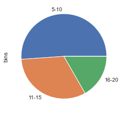

```python
subjects_20_asd['bins'] = pd.cut(subjects_20_asd['Age'],bins=[0,5,10,15,20], labels=["0-4","5-10","11-15","16-20"])
bins = subjects_20_asd.groupby('bins').size()
bins = subjects_20_asd['bins'].value_counts()
print(bins)
# Plot the age bins
bins.plot.pie(figsize=(4,4))
```

# Data Analysis

```python
# load the dataset after obtaining the Power spectral densities
data = OFH.OFHandlers.load_object('C:/Users/Akshay/Desktop/thesis/preprocessed_train_data.file')
data.tail()
```

|  | 0 | 1 | 2 | 3 | 4 | 5 | 6 | 7 | 8 | 9 | ... | 431 | 432 | 433 | 434 | 435 | 436 | 437 | 438 | 439 | target |
| --- | --- | --- | --- | --- | --- | --- | --- | --- | --- | --- | --- | --- | --- | --- | --- | --- | --- | --- | --- | --- | --- |
| 792 | 0.818169 | 0.056980 | 0.070925 | 0.053926 | 0.933126 | 0.029711 | 0.015757 | 0.021406 | 0.915639 | 0.033122 | ... | 0.019172 | 0.910909 | 0.034202 | 0.030270 | 0.024619 | 0.920132 | 0.037136 | 0.019048 | 0.023684 | 1 |
| 793 | 0.752046 | 0.076761 | 0.110924 | 0.060269 | 0.958963 | 0.017574 | 0.011148 | 0.012315 | 0.929162 | 0.023279 | ... | 0.011755 | 0.937943 | 0.017257 | 0.031004 | 0.013797 | 0.947894 | 0.018977 | 0.016732 | 0.016397 | 1 |
| 794 | 0.757489 | 0.075049 | 0.098404 | 0.069058 | 0.939620 | 0.024906 | 0.015857 | 0.019617 | 0.905081 | 0.031326 | ... | 0.016602 | 0.901232 | 0.027999 | 0.044387 | 0.026382 | 0.933138 | 0.023643 | 0.023088 | 0.020132 | 1 |
| 795 | 0.787527 | 0.064019 | 0.086282 | 0.062172 | 0.941163 | 0.020654 | 0.016628 | 0.021554 | 0.908215 | 0.026696 | ... | 0.019175 | 0.912551 | 0.023370 | 0.042159 | 0.021920 | 0.927776 | 0.024740 | 0.023106 | 0.024378 | 1 |
| 796 | 0.758210 | 0.080225 | 0.100270 | 0.061295 | 0.927749 | 0.033877 | 0.018180 | 0.020194 | 0.873578 | 0.045193 | ... | 0.019986 | 0.878537 | 0.042230 | 0.052688 | 0.026546 | 0.912452 | 0.037332 | 0.025007 | 0.025209 | 1 |

5 rows × 441 columns

Calculate the prevalence of the positive class : Prevalence is the proportion of a population who are positive to autism spectrum disorder in a given time period.

```python
def calc_prevalence(target):
    # this function calculates the prevalence of the positive class (label = 1)
    return sum(target) / len(target)


print(
    "prevalence of the positive class: %.3f"
    % calc_prevalence(data["target"].values)
)
```

```
prevalence of the positive class: 0.498
```

```python
# splitting data into positive and negative cases
rows_pos = data.target == 1
df_train_pos = data.loc[rows_pos]
df_train_neg = data.loc[~rows_pos]

# len(df_train_pos) = 397
# len(df_train_neg) = 400
n = np.min([len(df_train_pos), len(df_train_neg)])

# merge the balanced data
df_train = pd.concat([df_train_pos.sample(n=n, random_state=69), df_train_neg.sample(n=n, random_state=69)], axis=0, ignore_index=True)

# shuffle the order of the training sample
# df_train = df_train.sample(n=len(df_train), random_state=69).reset_index(drop=True)

print('Train balanced prevalence(n = %d):%.3f'%(len(df_train), calc_prevalence(df_train.target.values)))
```

```
Train balanced prevalence(n = 794):0.500
```

Now the data is balanced

```python
# separate feature and target variables from the above dataset
X = df_train.iloc[:,0:440].values
y = df_train['target'].astype('float')
```

Here, target column = 1 -> ASD and target column = 0 -> Normal

# Splitting data into train and validation sets

```python
X_train, X_valid, y_train, y_valid = train_test_split(X, y, test_size=0.2, random_state=0)
```

# PCA for dimensionality reduction

Using dimension reduction, we can approximate the original dataset with fewer variables, while reducing computational power to run our model. Using PCA, we can study the cumulative explained variance ratio of these features to understand which features explain the most variance in the data.

```python
pca = PCA(0.95)
X_train = pca.fit_transform(X_train)
X_valid = pca.transform(X_valid)
explained_variance = pca.explained_variance_ratio_
```

[figure not shown]

```python
# Lets just visualise first and second principal components
Xax=X_train[:,0]
Yax=X_train[:,1]
labels=y_train
cdict={0:'red',1:'green'}
labl={0:'asd',1:'normal'}
marker={0:'*',1:'o'}
alpha={0:.3, 1:.5}
fig,ax=plt.subplots(figsize=(7,5))
fig.patch.set_facecolor('white')
for l in np.unique(labels):
 ix=np.where(labels==l)
 ax.scatter(Xax[ix],Yax[ix],c=cdict[l],s=40,
           label=labl[l],marker=marker[l],alpha=alpha[l])
# for loop ends
plt.xlabel("First Principal Component",fontsize=14)
plt.ylabel("Second Principal Component",fontsize=14)
plt.legend()
plt.show()
# please check the scatter plot of the remaining component and you will understand the difference
```

```python
# Check dimension after pca
print(X_train.shape)
print(X_valid.shape)
print(y_train.shape)
print(y_valid.shape)
```

```
(635, 46)
(159, 46)
(635,)
(159,)
```

```python
# Lets check the correlation of features
pca = PCA(0.95)
dfpca= pca.fit_transform(X)
df_pca = pd.DataFrame(dfpca)
y_df = pd.DataFrame(y)
df = pd.concat([df_pca,y_df],axis=1)
corr = df.corr()
corr.style.background_gradient(cmap='coolwarm').set_precision(2)
```

|  | 0 | 1 | 2 | 3 | 4 | 5 | 6 | 7 | 8 | 9 | 10 | 11 | 12 | 13 | 14 | 15 | 16 | 17 | 18 | 19 | 20 | 21 | 22 | 23 | 24 | 25 | 26 | 27 | 28 | … |
| --- | --- | --- | --- | --- | --- | --- | --- | --- | --- | --- | --- | --- | --- | --- | --- | --- | --- | --- | --- | --- | --- | --- | --- | --- | --- | --- | --- | --- | --- | --- |
| 0 | 1.00 | -0.00 | 0.00 | 0.00 | 0.00 | -0.00 | 0.00 | -0.00 | -0.00 | -0.00 | 0.00 | -0.00 | -0.00 | -0.00 | -0.00 | -0.00 | -0.00 | 0.00 | 0.00 | -0.00 | 0.00 | -0.00 | 0.00 | -0.00 | 0.00 | 0.00 | 0.00 | -0.00 | -0.00 | … |
| 1 | -0.00 | 1.00 | 0.00 | -0.00 | 0.00 | -0.00 | -0.00 | 0.00 | 0.00 | -0.00 | -0.00 | -0.00 | 0.00 | 0.00 | -0.00 | 0.00 | 0.00 | 0.00 | -0.00 | -0.00 | 0.00 | -0.00 | 0.00 | -0.00 | 0.00 | -0.00 | 0.00 | 0.00 | -0.00 | … |
| 2 | 0.00 | 0.00 | 1.00 | 0.00 | -0.00 | -0.00 | -0.00 | 0.00 | -0.00 | -0.00 | -0.00 | -0.00 | 0.00 | 0.00 | 0.00 | 0.00 | -0.00 | -0.00 | 0.00 | 0.00 | -0.00 | -0.00 | 0.00 | -0.00 | -0.00 | 0.00 | 0.00 | -0.00 | 0.00 | … |
| 3 | 0.00 | -0.00 | 0.00 | 1.00 | 0.00 | 0.00 | 0.00 | 0.00 | -0.00 | 0.00 | 0.00 | -0.00 | 0.00 | 0.00 | -0.00 | -0.00 | 0.00 | 0.00 | -0.00 | -0.00 | 0.00 | 0.00 | -0.00 | 0.00 | 0.00 | -0.00 | -0.00 | -0.00 | -0.00 | … |
| 4 | 0.00 | 0.00 | -0.00 | 0.00 | 1.00 | 0.00 | -0.00 | -0.00 | -0.00 | -0.00 | 0.00 | -0.00 | -0.00 | -0.00 | -0.00 | -0.00 | 0.00 | -0.00 | -0.00 | -0.00 | 0.00 | -0.00 | -0.00 | -0.00 | -0.00 | 0.00 | 0.00 | -0.00 | 0.00 | … |
| 5 | -0.00 | -0.00 | -0.00 | 0.00 | 0.00 | 1.00 | -0.00 | 0.00 | -0.00 | 0.00 | -0.00 | -0.00 | 0.00 | -0.00 | 0.00 | 0.00 | -0.00 | -0.00 | -0.00 | 0.00 | -0.00 | 0.00 | -0.00 | 0.00 | 0.00 | -0.00 | 0.00 | 0.00 | 0.00 | … |
| 6 | 0.00 | -0.00 | -0.00 | 0.00 | -0.00 | -0.00 | 1.00 | -0.00 | 0.00 | 0.00 | 0.00 | 0.00 | -0.00 | 0.00 | -0.00 | 0.00 | 0.00 | 0.00 | 0.00 | 0.00 | -0.00 | -0.00 | 0.00 | 0.00 | -0.00 | -0.00 | 0.00 | -0.00 | -0.00 | … |
| 7 | -0.00 | 0.00 | 0.00 | 0.00 | -0.00 | 0.00 | -0.00 | 1.00 | 0.00 | 0.00 | 0.00 | 0.00 | 0.00 | -0.00 | -0.00 | -0.00 | 0.00 | 0.00 | 0.00 | 0.00 | 0.00 | -0.00 | 0.00 | -0.00 | -0.00 | 0.00 | -0.00 | -0.00 | 0.00 | … |
| 8 | -0.00 | 0.00 | -0.00 | -0.00 | -0.00 | -0.00 | 0.00 | 0.00 | 1.00 | -0.00 | 0.00 | -0.00 | -0.00 | -0.00 | -0.00 | -0.00 | -0.00 | -0.00 | 0.00 | -0.00 | 0.00 | 0.00 | -0.00 | -0.00 | 0.00 | -0.00 | -0.00 | 0.00 | -0.00 | … |
| 9 | -0.00 | -0.00 | -0.00 | 0.00 | -0.00 | 0.00 | 0.00 | 0.00 | -0.00 | 1.00 | 0.00 | -0.00 | -0.00 | 0.00 | 0.00 | -0.00 | -0.00 | 0.00 | 0.00 | -0.00 | -0.00 | 0.00 | -0.00 | 0.00 | -0.00 | 0.00 | -0.00 | 0.00 | -0.00 | … |
| 10 | 0.00 | -0.00 | -0.00 | 0.00 | 0.00 | -0.00 | 0.00 | 0.00 | 0.00 | 0.00 | 1.00 | -0.00 | -0.00 | 0.00 | -0.00 | 0.00 | 0.00 | 0.00 | -0.00 | -0.00 | -0.00 | 0.00 | 0.00 | 0.00 | 0.00 | 0.00 | 0.00 | -0.00 | -0.00 | … |
| 11 | -0.00 | -0.00 | -0.00 | -0.00 | -0.00 | -0.00 | 0.00 | 0.00 | -0.00 | -0.00 | -0.00 | 1.00 | -0.00 | -0.00 | 0.00 | -0.00 | 0.00 | -0.00 | -0.00 | 0.00 | -0.00 | -0.00 | -0.00 | 0.00 | 0.00 | 0.00 | 0.00 | 0.00 | 0.00 | … |
| 12 | -0.00 | 0.00 | 0.00 | 0.00 | -0.00 | 0.00 | -0.00 | 0.00 | -0.00 | -0.00 | -0.00 | -0.00 | 1.00 | -0.00 | 0.00 | 0.00 | 0.00 | -0.00 | -0.00 | -0.00 | 0.00 | 0.00 | 0.00 | -0.00 | -0.00 | 0.00 | 0.00 | 0.00 | -0.00 | … |
| 13 | -0.00 | 0.00 | 0.00 | 0.00 | -0.00 | -0.00 | 0.00 | -0.00 | -0.00 | 0.00 | 0.00 | -0.00 | -0.00 | 1.00 | 0.00 | 0.00 | 0.00 | 0.00 | 0.00 | 0.00 | 0.00 | -0.00 | 0.00 | -0.00 | 0.00 | -0.00 | -0.00 | 0.00 | 0.00 | … |
| 14 | -0.00 | -0.00 | 0.00 | -0.00 | -0.00 | 0.00 | -0.00 | -0.00 | -0.00 | 0.00 | -0.00 | 0.00 | 0.00 | 0.00 | 1.00 | -0.00 | 0.00 | -0.00 | 0.00 | -0.00 | 0.00 | 0.00 | 0.00 | 0.00 | -0.00 | 0.00 | -0.00 | 0.00 | 0.00 | … |
| 15 | -0.00 | 0.00 | 0.00 | -0.00 | -0.00 | 0.00 | 0.00 | -0.00 | -0.00 | -0.00 | 0.00 | -0.00 | 0.00 | 0.00 | -0.00 | 1.00 | -0.00 | 0.00 | -0.00 | 0.00 | -0.00 | 0.00 | 0.00 | -0.00 | 0.00 | -0.00 | 0.00 | -0.00 | 0.00 | … |
| 16 | -0.00 | 0.00 | -0.00 | 0.00 | 0.00 | -0.00 | 0.00 | 0.00 | -0.00 | -0.00 | 0.00 | 0.00 | 0.00 | 0.00 | 0.00 | -0.00 | 1.00 | 0.00 | -0.00 | 0.00 | 0.00 | 0.00 | 0.00 | 0.00 | 0.00 | -0.00 | -0.00 | 0.00 | -0.00 | … |
| 17 | 0.00 | 0.00 | -0.00 | 0.00 | -0.00 | -0.00 | 0.00 | 0.00 | -0.00 | 0.00 | 0.00 | -0.00 | -0.00 | 0.00 | -0.00 | 0.00 | 0.00 | 1.00 | -0.00 | 0.00 | -0.00 | 0.00 | 0.00 | 0.00 | 0.00 | 0.00 | 0.00 | -0.00 | 0.00 | … |
| 18 | 0.00 | -0.00 | 0.00 | -0.00 | -0.00 | -0.00 | 0.00 | 0.00 | 0.00 | 0.00 | -0.00 | -0.00 | -0.00 | 0.00 | 0.00 | -0.00 | -0.00 | -0.00 | 1.00 | 0.00 | 0.00 | -0.00 | 0.00 | -0.00 | 0.00 | -0.00 | 0.00 | -0.00 | -0.00 | … |
| 19 | -0.00 | -0.00 | 0.00 | -0.00 | -0.00 | 0.00 | 0.00 | 0.00 | -0.00 | -0.00 | -0.00 | 0.00 | -0.00 | 0.00 | -0.00 | 0.00 | 0.00 | 0.00 | 0.00 | 1.00 | 0.00 | 0.00 | 0.00 | -0.00 | -0.00 | 0.00 | -0.00 | 0.00 | 0.00 | … |
| 20 | 0.00 | 0.00 | -0.00 | 0.00 | 0.00 | -0.00 | -0.00 | 0.00 | 0.00 | -0.00 | -0.00 | -0.00 | 0.00 | 0.00 | 0.00 | -0.00 | 0.00 | -0.00 | 0.00 | 0.00 | 1.00 | 0.00 | -0.00 | -0.00 | -0.00 | 0.00 | 0.00 | -0.00 | -0.00 | … |
| 21 | -0.00 | -0.00 | -0.00 | 0.00 | -0.00 | 0.00 | -0.00 | -0.00 | 0.00 | 0.00 | 0.00 | -0.00 | 0.00 | -0.00 | 0.00 | 0.00 | 0.00 | 0.00 | -0.00 | 0.00 | 0.00 | 1.00 | -0.00 | 0.00 | 0.00 | -0.00 | 0.00 | -0.00 | 0.00 | … |
| 22 | 0.00 | 0.00 | 0.00 | -0.00 | -0.00 | -0.00 | 0.00 | 0.00 | -0.00 | -0.00 | 0.00 | -0.00 | 0.00 | 0.00 | 0.00 | 0.00 | 0.00 | 0.00 | 0.00 | 0.00 | -0.00 | -0.00 | 1.00 | 0.00 | 0.00 | 0.00 | -0.00 | 0.00 | -0.00 | … |
| 23 | -0.00 | -0.00 | -0.00 | 0.00 | -0.00 | 0.00 | 0.00 | -0.00 | -0.00 | 0.00 | 0.00 | 0.00 | -0.00 | -0.00 | 0.00 | -0.00 | 0.00 | 0.00 | -0.00 | -0.00 | -0.00 | 0.00 | 0.00 | 1.00 | -0.00 | 0.00 | -0.00 | 0.00 | 0.00 | … |
| 24 | 0.00 | 0.00 | -0.00 | 0.00 | -0.00 | 0.00 | -0.00 | -0.00 | 0.00 | -0.00 | 0.00 | 0.00 | -0.00 | 0.00 | -0.00 | 0.00 | 0.00 | 0.00 | 0.00 | -0.00 | -0.00 | 0.00 | 0.00 | -0.00 | 1.00 | 0.00 | -0.00 | 0.00 | 0.00 | … |
| 25 | 0.00 | -0.00 | 0.00 | -0.00 | 0.00 | -0.00 | -0.00 | 0.00 | -0.00 | 0.00 | 0.00 | 0.00 | 0.00 | -0.00 | 0.00 | -0.00 | -0.00 | 0.00 | -0.00 | 0.00 | 0.00 | -0.00 | 0.00 | 0.00 | 0.00 | 1.00 | 0.00 | -0.00 | -0.00 | … |
| 26 | 0.00 | 0.00 | 0.00 | -0.00 | 0.00 | 0.00 | 0.00 | -0.00 | -0.00 | -0.00 | 0.00 | 0.00 | 0.00 | -0.00 | -0.00 | 0.00 | -0.00 | 0.00 | 0.00 | -0.00 | 0.00 | 0.00 | -0.00 | -0.00 | -0.00 | 0.00 | 1.00 | -0.00 | -0.00 | … |
| 27 | -0.00 | 0.00 | -0.00 | -0.00 | -0.00 | 0.00 | -0.00 | -0.00 | 0.00 | 0.00 | -0.00 | 0.00 | 0.00 | 0.00 | 0.00 | -0.00 | 0.00 | -0.00 | -0.00 | 0.00 | -0.00 | -0.00 | 0.00 | 0.00 | 0.00 | -0.00 | -0.00 | 1.00 | 0.00 | … |
| 28 | -0.00 | -0.00 | 0.00 | -0.00 | 0.00 | 0.00 | -0.00 | 0.00 | -0.00 | -0.00 | -0.00 | 0.00 | -0.00 | 0.00 | 0.00 | 0.00 | -0.00 | 0.00 | -0.00 | 0.00 | -0.00 | 0.00 | -0.00 | 0.00 | 0.00 | -0.00 | -0.00 | 0.00 | 1.00 | … |
| 29 | -0.00 | 0.00 | -0.00 | 0.00 | 0.00 | -0.00 | -0.00 | -0.00 | -0.00 | 0.00 | -0.00 | 0.00 | -0.00 | -0.00 | -0.00 | -0.00 | 0.00 | 0.00 | -0.00 | 0.00 | -0.00 | -0.00 | 0.00 | -0.00 | -0.00 | 0.00 | -0.00 | 0.00 | -0.00 | … |
| 30 | 0.00 | -0.00 | 0.00 | -0.00 | -0.00 | -0.00 | -0.00 | -0.00 | -0.00 | -0.00 | 0.00 | 0.00 | -0.00 | -0.00 | 0.00 | 0.00 | -0.00 | -0.00 | 0.00 | 0.00 | -0.00 | -0.00 | 0.00 | 0.00 | 0.00 | -0.00 | -0.00 | 0.00 | -0.00 | … |
| 31 | 0.00 | 0.00 | 0.00 | 0.00 | 0.00 | 0.00 | -0.00 | -0.00 | 0.00 | 0.00 | 0.00 | 0.00 | -0.00 | -0.00 | 0.00 | -0.00 | -0.00 | 0.00 | -0.00 | -0.00 | -0.00 | -0.00 | 0.00 | -0.00 | 0.00 | -0.00 | 0.00 | 0.00 | 0.00 | … |
| 32 | 0.00 | -0.00 | -0.00 | 0.00 | 0.00 | -0.00 | 0.00 | -0.00 | -0.00 | -0.00 | 0.00 | -0.00 | 0.00 | 0.00 | 0.00 | 0.00 | 0.00 | -0.00 | 0.00 | 0.00 | 0.00 | 0.00 | 0.00 | -0.00 | 0.00 | 0.00 | 0.00 | -0.00 | 0.00 | … |
| 33 | -0.00 | -0.00 | -0.00 | -0.00 | 0.00 | 0.00 | 0.00 | -0.00 | 0.00 | 0.00 | 0.00 | -0.00 | 0.00 | 0.00 | 0.00 | -0.00 | 0.00 | 0.00 | -0.00 | 0.00 | 0.00 | -0.00 | 0.00 | 0.00 | -0.00 | 0.00 | 0.00 | -0.00 | -0.00 | … |
| 34 | -0.00 | -0.00 | -0.00 | 0.00 | 0.00 | 0.00 | -0.00 | -0.00 | 0.00 | 0.00 | 0.00 | 0.00 | 0.00 | 0.00 | 0.00 | 0.00 | -0.00 | 0.00 | -0.00 | 0.00 | 0.00 | -0.00 | 0.00 | 0.00 | -0.00 | 0.00 | -0.00 | -0.00 | 0.00 | … |
| 35 | 0.00 | -0.00 | 0.00 | 0.00 | -0.00 | 0.00 | -0.00 | -0.00 | 0.00 | -0.00 | -0.00 | 0.00 | -0.00 | -0.00 | -0.00 | 0.00 | -0.00 | -0.00 | 0.00 | 0.00 | -0.00 | 0.00 | 0.00 | -0.00 | -0.00 | -0.00 | -0.00 | 0.00 | 0.00 | … |
| 36 | 0.00 | 0.00 | 0.00 | 0.00 | 0.00 | 0.00 | -0.00 | 0.00 | 0.00 | 0.00 | -0.00 | 0.00 | 0.00 | -0.00 | 0.00 | -0.00 | 0.00 | -0.00 | 0.00 | -0.00 | 0.00 | 0.00 | 0.00 | -0.00 | 0.00 | -0.00 | 0.00 | -0.00 | 0.00 | … |
| 37 | 0.00 | -0.00 | -0.00 | -0.00 | -0.00 | -0.00 | -0.00 | 0.00 | 0.00 | -0.00 | -0.00 | -0.00 | 0.00 | -0.00 | 0.00 | -0.00 | 0.00 | 0.00 | 0.00 | -0.00 | -0.00 | 0.00 | -0.00 | 0.00 | 0.00 | -0.00 | -0.00 | -0.00 | 0.00 | … |
| 38 | -0.00 | -0.00 | 0.00 | -0.00 | 0.00 | 0.00 | 0.00 | 0.00 | 0.00 | 0.00 | -0.00 | 0.00 | 0.00 | 0.00 | -0.00 | 0.00 | 0.00 | -0.00 | -0.00 | 0.00 | 0.00 | -0.00 | -0.00 | 0.00 | 0.00 | 0.00 | -0.00 | 0.00 | 0.00 | … |
| 39 | -0.00 | -0.00 | 0.00 | -0.00 | 0.00 | -0.00 | 0.00 | 0.00 | 0.00 | 0.00 | 0.00 | 0.00 | 0.00 | -0.00 | -0.00 | -0.00 | -0.00 | -0.00 | 0.00 | 0.00 | 0.00 | -0.00 | 0.00 | 0.00 | -0.00 | 0.00 | 0.00 | 0.00 | 0.00 | … |
| 40 | 0.00 | 0.00 | 0.00 | 0.00 | -0.00 | 0.00 | 0.00 | 0.00 | 0.00 | -0.00 | 0.00 | -0.00 | 0.00 | -0.00 | -0.00 | -0.00 | 0.00 | -0.00 | 0.00 | -0.00 | 0.00 | -0.00 | 0.00 | 0.00 | 0.00 | 0.00 | 0.00 | 0.00 | 0.00 | … |
| 41 | -0.00 | -0.00 | -0.00 | -0.00 | -0.00 | -0.00 | 0.00 | 0.00 | 0.00 | 0.00 | 0.00 | -0.00 | -0.00 | 0.00 | 0.00 | 0.00 | 0.00 | 0.00 | -0.00 | 0.00 | -0.00 | -0.00 | -0.00 | 0.00 | -0.00 | 0.00 | -0.00 | -0.00 | 0.00 | … |
| 42 | 0.00 | 0.00 | -0.00 | -0.00 | -0.00 | 0.00 | -0.00 | -0.00 | -0.00 | -0.00 | 0.00 | 0.00 | -0.00 | -0.00 | 0.00 | -0.00 | -0.00 | -0.00 | 0.00 | -0.00 | -0.00 | 0.00 | -0.00 | -0.00 | -0.00 | -0.00 | 0.00 | 0.00 | 0.00 | … |
| 43 | 0.00 | 0.00 | 0.00 | -0.00 | -0.00 | -0.00 | 0.00 | 0.00 | 0.00 | 0.00 | 0.00 | -0.00 | 0.00 | 0.00 | 0.00 | 0.00 | 0.00 | 0.00 | -0.00 | -0.00 | 0.00 | -0.00 | -0.00 | 0.00 | -0.00 | -0.00 | -0.00 | -0.00 | -0.00 | … |
| 44 | -0.00 | -0.00 | -0.00 | 0.00 | 0.00 | -0.00 | 0.00 | 0.00 | 0.00 | -0.00 | -0.00 | 0.00 | 0.00 | 0.00 | 0.00 | -0.00 | 0.00 | 0.00 | 0.00 | 0.00 | -0.00 | 0.00 | -0.00 | 0.00 | 0.00 | -0.00 | 0.00 | 0.00 | 0.00 | … |
| 45 | 0.00 | 0.00 | 0.00 | -0.00 | 0.00 | 0.00 | -0.00 | -0.00 | -0.00 | -0.00 | 0.00 | -0.00 | -0.00 | -0.00 | -0.00 | 0.00 | 0.00 | -0.00 | 0.00 | -0.00 | -0.00 | 0.00 | -0.00 | 0.00 | -0.00 | 0.00 | -0.00 | -0.00 | -0.00 | … |
| 46 | 0.00 | -0.00 | 0.00 | -0.00 | 0.00 | -0.00 | 0.00 | -0.00 | 0.00 | 0.00 | 0.00 | -0.00 | -0.00 | -0.00 | -0.00 | -0.00 | -0.00 | -0.00 | 0.00 | 0.00 | -0.00 | 0.00 | 0.00 | -0.00 | -0.00 | 0.00 | 0.00 | 0.00 | -0.00 | … |
| target | -0.01 | 0.01 | -0.17 | 0.13 | -0.07 | 0.16 | 0.00 | 0.05 | 0.05 | -0.01 | 0.01 | -0.05 | 0.11 | -0.08 | 0.05 | -0.03 | -0.06 | -0.04 | 0.04 | -0.05 | 0.09 | -0.01 | -0.12 | -0.09 | -0.00 | -0.02 | 0.01 | 0.10 | 0.08 | … |

# Model Selection

Print all our model metrics with one function print_report()

```python
from sklearn.metrics import roc_auc_score, accuracy_score, precision_score, recall_score

def calc_specificity(y_actual, y_pred, thresh):
    # calculates specificity
    return sum((y_pred < thresh) & (y_actual == 0)) /sum(y_actual ==0)

def print_report(y_actual, y_pred, thresh):

    auc = roc_auc_score(y_actual, y_pred)
    accuracy = accuracy_score(y_actual, (y_pred > thresh))
    recall = recall_score(y_actual, (y_pred > thresh))
    precision = precision_score(y_actual, (y_pred > thresh))
    specificity = calc_specificity(y_actual, y_pred, thresh)
    print('AUC:%.3f'%auc)
    print('accuracy:%.3f'%accuracy)
    print('recall:%.3f'%recall)
    print('precision:%.3f'%precision)
    print('specificity:%.3f'%specificity)
    print('prevalence:%.3f'%calc_prevalence(y_actual))
    print(' ')
    return auc, accuracy, recall, precision, specificity
```

**Hypothesis** : Let's set our threshold at 0.5 to label a predicted sample as positive.

```python
thresh = 0.5
```

# 1. KNN

```python
from sklearn.neighbors import KNeighborsClassifier
knn=KNeighborsClassifier(n_neighbors = 1)
knn.fit(X_train, y_train)
y_train_preds = knn.predict_proba(X_train)[:,1]
y_valid_preds = knn.predict_proba(X_valid)[:,1]

print('KNN')
print('Training:')
knn_train_auc, knn_train_accuracy, knn_train_recall, \
    knn_train_precision, knn_train_specificity = print_report(y_train,y_train_preds, thresh)
print('Validation:')
knn_valid_auc, knn_valid_accuracy, knn_valid_recall, \
    knn_valid_precision, knn_valid_specificity = print_report(y_valid,y_valid_preds, thresh)
```

```
KNN
Training:
AUC:1.000
accuracy:1.000
recall:1.000
precision:1.000
specificity:1.000
prevalence:0.501

Validation:
AUC:0.937
accuracy:0.937
recall:0.899
precision:0.973
specificity:0.975
prevalence:0.497
```

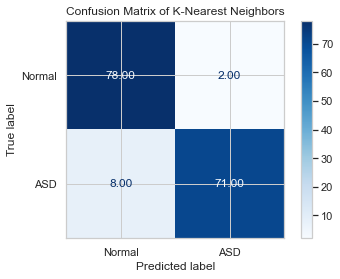

```python
# Lets plot the confusion matrix
plot_confusion_matrix(knn, X_valid, y_valid,
                      display_labels = ['Normal','ASD'],
                      cmap = plt.cm.Blues,
                      values_format = ".2f")
plt.title('Confusion Matrix of K-Nearest Neighbors')
plt.show()
```

# Logistic Regression

```python
from sklearn.linear_model import LogisticRegression
lr = LogisticRegression(random_state = 69)
lr.fit(X_train, y_train)

# predict_prob gives the probability of getting output as 1 for each observation
y_train_preds = lr.predict_proba(X_train)[:,1]
y_valid_preds = lr.predict_proba(X_valid)[:,1]

print('Logistic Regression')
print('Training:')
lr_train_auc, lr_train_accuracy, lr_train_recall, \
    lr_train_precision, lr_train_specificity = print_report(y_train,y_train_preds, thresh)
print('Validation:')
lr_valid_auc, lr_valid_accuracy, lr_valid_recall, \
    lr_valid_precision, lr_valid_specificity = print_report(y_valid,y_valid_preds, thresh)
```

```
Logistic Regression
Training:
AUC:0.779
accuracy:0.701
recall:0.758
precision:0.681
specificity:0.644
prevalence:0.501

Validation:
AUC:0.710
accuracy:0.635
recall:0.684
precision:0.621
specificity:0.588
prevalence:0.497
```

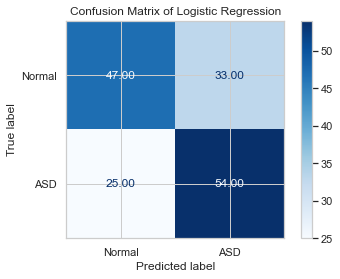

```python
# Lets plot the confusion matrix
plot_confusion_matrix(lr, X_valid, y_valid,
                      display_labels = ['Normal','ASD'],
                      cmap = plt.cm.Blues,
                      values_format = ".2f")
plt.title('Confusion Matrix of Logistic Regression')
plt.show()
```

# Decision Tree Classifier

```python
from sklearn.tree import DecisionTreeClassifier
tree = DecisionTreeClassifier(max_depth = 10, random_state = 69)
tree.fit(X_train, y_train)

y_train_preds = tree.predict_proba(X_train)[:,1]
y_valid_preds = tree.predict_proba(X_valid)[:,1]

print('Decision Tree')
print('Training:')
tree_train_auc, tree_train_accuracy, tree_train_recall, tree_train_precision, \
tree_train_specificity =print_report(y_train,y_train_preds, thresh)
print('Validation:')
tree_valid_auc, tree_valid_accuracy, tree_valid_recall, tree_valid_precision, \
tree_valid_specificity = print_report(y_valid,y_valid_preds, thresh)
```

```
Decision Tree
Training:
AUC:0.997
accuracy:0.976
recall:0.984
precision:0.969
specificity:0.968
prevalence:0.501

Validation:
AUC:0.758
accuracy:0.761
recall:0.747
precision:0.766
specificity:0.775
prevalence:0.497
```

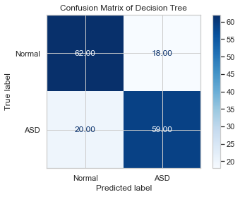

```python
# Lets plot the confusion matrix
plot_confusion_matrix(tree, X_valid, y_valid,
                      display_labels = ['Normal','ASD'],
                      cmap = plt.cm.Blues,
                      values_format = ".2f")
plt.title('Confusion Matrix of Decision Tree')
plt.show()
```

# Random Forest

```python
from sklearn.ensemble import RandomForestClassifier
rf = RandomForestClassifier(random_state = 69)
rf.fit(X_train, y_train)

y_train_preds = rf.predict_proba(X_train)[:,1]
y_valid_preds = rf.predict_proba(X_valid)[:,1]

print('Random Forest')
print('Training:')
rf_train_auc, rf_train_accuracy, rf_train_recall, rf_train_precision, \
rf_train_specificity =print_report(y_train,y_train_preds, thresh)
print('Validation:')
rf_valid_auc, rf_valid_accuracy, rf_valid_recall, rf_valid_precision, \
rf_valid_specificity = print_report(y_valid,y_valid_preds, thresh)
```

```
Random Forest
Training:
AUC:1.000
accuracy:1.000
recall:1.000
precision:1.000
specificity:1.000
prevalence:0.501

Validation:
AUC:1.000
accuracy:0.969
recall:0.937
precision:1.000
specificity:1.000
prevalence:0.497
```

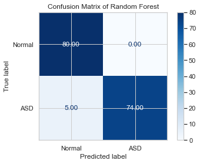

```python
# Lets plot the confusion matrix
plot_confusion_matrix(rf, X_valid, y_valid,
                      display_labels = ['Normal','ASD'],
                      cmap = plt.cm.Blues,
                      values_format = ".2f")
plt.title('Confusion Matrix of Random Forest')
plt.show()
```

# Extremely Random Trees

```python
from sklearn.ensemble import ExtraTreesClassifier
from sklearn.feature_selection import RFE
from sklearn.pipeline import make_pipeline
from sklearn.preprocessing import MinMaxScaler
```

```python
etc = ExtraTreesClassifier(bootstrap=False, criterion="entropy", max_features=1.0,
                           min_samples_leaf=3, min_samples_split=20, n_estimators=100)
etc.fit(X_train, y_train)

y_train_preds = etc.predict_proba(X_train)[:, 1]
y_valid_preds = etc.predict_proba(X_valid)[:, 1]

print('Extra Trees Classifier')
print('Training:')
etc_train_auc, etc_train_accuracy, etc_train_recall, etc_train_precision, \
etc_train_specificity = print_report(y_train, y_train_preds, thresh)
print('Validation:')
etc_valid_auc, etc_valid_accuracy, etc_valid_recall, etc_valid_precision, \
etc_valid_specificity = print_report(y_valid, y_valid_preds, thresh)
```

```
Extra Trees Classifier
Training:
AUC:1.000
accuracy:1.000
recall:1.000
precision:1.000
specificity:1.000
prevalence:0.501

Validation:
AUC:0.999
accuracy:0.975
recall:0.962
precision:0.987
specificity:0.988
prevalence:0.497
```

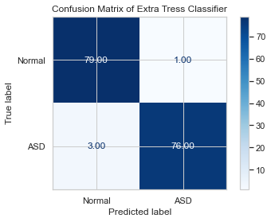

```python
# Lets plot the confusion matrix
plot_confusion_matrix(etc, X_valid, y_valid,
                      display_labels = ['Normal','ASD'],
                      cmap = plt.cm.Blues,
                      values_format = ".2f")
plt.title('Confusion Matrix of Extra Tress Classifier')
plt.show()
```

# XGboost

```python
from xgboost import XGBClassifier
import xgboost as xgb
xgbc = XGBClassifier()
xgbc.fit(X_train, y_train)

y_train_preds = xgbc.predict_proba(X_train)[:,1]
y_valid_preds = xgbc.predict_proba(X_valid)[:,1]

print('Xtreme Gradient Boosting Classifier')
print('Training:')
xgbc_train_auc, xgbc_train_accuracy, xgbc_train_recall, xgbc_train_precision, \
xgbc_train_specificity = print_report(y_train,y_train_preds, thresh)
print('Validation:')
xgbc_valid_auc, xgbc_valid_accuracy, xgbc_valid_recall, xgbc_valid_precision, \
xgbc_valid_specificity = print_report(y_valid,y_valid_preds, thresh)
```

```
Xtreme Gradient Boosting Classifier
Training:
AUC:1.000
accuracy:1.000
recall:1.000
precision:1.000
specificity:1.000
prevalence:0.501

Validation:
AUC:0.995
accuracy:0.950
recall:0.924
precision:0.973
specificity:0.975
prevalence:0.497
```

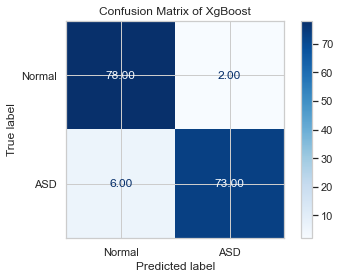

```python
# Lets plot the confusion matrix
plot_confusion_matrix(xgbc, X_valid, y_valid,
                      display_labels = ['Normal','ASD'],
                      cmap = plt.cm.Blues,
                      values_format = ".2f")
plt.title('Confusion Matrix of XgBoost')
plt.show()
```

# Analysis of baseline models

```python
df_results = pd.DataFrame({'classifier':['KNN','KNN','LR','LR','DT','DT','RF','RF','XGBC','XGBC','ETC','ETC'],
                           'data_set':['train','valid']*6,
                          'auc':[knn_train_auc, knn_valid_auc,lr_train_auc,lr_valid_auc,tree_train_auc,tree_valid_auc,rf_train_auc,rf_valid_auc,xgbc_train_auc,xgbc_valid_auc,etc_train_auc,etc_valid_auc],
                          'accuracy':[knn_train_accuracy, knn_valid_accuracy,lr_train_accuracy,lr_valid_accuracy,tree_train_accuracy,tree_valid_accuracy,rf_train_accuracy,rf_valid_accuracy,xgbc_train_accuracy,xgbc_valid_accuracy,etc_train_accuracy,etc_valid_accuracy],
                          'recall':[knn_train_recall, knn_valid_recall,lr_train_recall,lr_valid_recall,tree_train_recall,tree_valid_recall,rf_train_recall,rf_valid_recall,xgbc_train_recall,xgbc_valid_recall,etc_train_recall,etc_valid_recall],
                          'precision':[knn_train_precision, knn_valid_precision,lr_train_precision,lr_valid_precision,tree_train_precision,tree_valid_precision,rf_train_precision,rf_valid_precision,xgbc_train_precision,xgbc_valid_precision,etc_train_precision,etc_valid_precision],
                          'specificity':[knn_train_specificity, knn_valid_specificity,lr_train_specificity,lr_valid_specificity,tree_train_specificity,tree_valid_specificity,rf_train_specificity,rf_valid_specificity,xgbc_train_specificity,xgbc_valid_specificity,etc_train_specificity,etc_valid_specificity]})
```

```python
df_results
```

|  | classifier | data_set | auc | accuracy | recall | precision | specificity |
| --- | --- | --- | --- | --- | --- | --- | --- |
| 0 | KNN | train | 1.000000 | 1.000000 | 1.000000 | 1.000000 | 1.000000 |
| 1 | KNN | valid | 0.936867 | 0.937107 | 0.898734 | 0.972603 | 0.975000 |
| 2 | LR | train | 0.778892 | 0.700787 | 0.757862 | 0.680791 | 0.643533 |
| 3 | LR | valid | 0.710443 | 0.635220 | 0.683544 | 0.620690 | 0.587500 |
| 4 | DT | train | 0.996900 | 0.976378 | 0.984277 | 0.969040 | 0.968454 |
| 5 | DT | valid | 0.757753 | 0.761006 | 0.746835 | 0.766234 | 0.775000 |
| 6 | RF | train | 1.000000 | 1.000000 | 1.000000 | 1.000000 | 1.000000 |
| 7 | RF | valid | 1.000000 | 0.968553 | 0.936709 | 1.000000 | 1.000000 |
| 8 | XGBC | train | 1.000000 | 1.000000 | 1.000000 | 1.000000 | 1.000000 |
| 9 | XGBC | valid | 0.994620 | 0.949686 | 0.924051 | 0.973333 | 0.975000 |
| 10 | ETC | train | 1.000000 | 1.000000 | 1.000000 | 1.000000 | 1.000000 |
| 11 | ETC | valid | 0.999051 | 0.974843 | 0.962025 | 0.987013 | 0.987500 |

The performance metric I chose will be the AUC score of the validation set. It is the most common score used to compare which model is best at classifying samples.

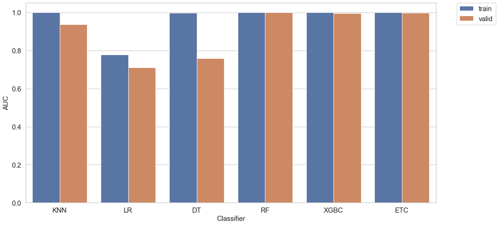

```python
sns.set_style("whitegrid")
plt.figure(figsize=(16, 8))
ax = sns.barplot(x = 'classifier', y = 'auc', hue = 'data_set', data = df_results)
ax.set_xlabel('Classifier', fontsize = 15)
ax.set_ylabel('AUC', fontsize = 15)
ax.tick_params(labelsize = 15)

#Separate legend from graph
plt.legend(bbox_to_anchor = (1.05, 1), loc = 2, borderaxespad = 0., fontsize = 15)
```

ExtraTrees Classfier algorithm is chosen for hyperparameter tunning

```python
# this is a quick way to tune one parameter of your model while holding everything else constant.
import time

my_params =  np.arange(0.05, 1.01, 0.05) # fill this in your list of parameters

# initialize arrays for storing the results
train_metrics = np.zeros(len(my_params))
valid_metrics = np.zeros(len(my_params))

# train a model for each param in a list
t1 = time.time()
for jj in range(len(my_params)):
    my_param = my_params[jj]

    # fit model
    model = ExtraTreesClassifier(bootstrap=False, criterion="entropy", max_features=my_param, min_samples_leaf=3, min_samples_split=20, n_estimators=100)
    model.fit(X_train, y_train)
    # get predictions
    y_train_preds = model.predict_proba(X_train)[:,1]
    y_valid_preds = model.predict_proba(X_valid)[:,1]

    # calculate auc
    metric_train = roc_auc_score(y_train, y_train_preds) # fill this in
    metric_valid = roc_auc_score(y_valid, y_valid_preds) # fill this in

    # save aucs
    train_metrics[jj] = metric_train
    valid_metrics[jj] = metric_valid

    # print the time
    t2 = time.time()
    print(my_param, t2-t1)
    t1 = time.time()
```

```
0.05 0.13591480255126953
0.1 0.1315774917602539
0.15000000000000002 0.1365208625793457
0.2 0.16725397109985352
0.25 0.17219257354736328
0.3 0.16239547729492188
0.35000000000000003 0.18464374542236328
0.4 0.18607211112976074
0.45 0.20917534828186035
0.5 0.19745326042175293
0.55 0.2124316692352295
0.6000000000000001 0.2141258716583252
0.6500000000000001 0.24436450004577637
0.7000000000000001 0.2442476749420166
0.7500000000000001 0.23783421516418457
0.8 0.2411181926727295
0.8500000000000001 0.2578256130218506
0.9000000000000001 0.300199031829834
0.9500000000000001 0.27273988723754883
1.0 0.2807886600494385
```

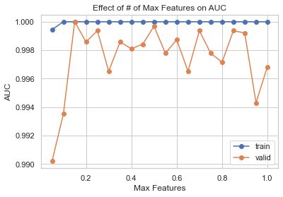

```python
plt.plot(my_params, train_metrics,'o-',label = 'train')
plt.plot(my_params, valid_metrics,'o-',label = 'valid')

plt.xlabel('Max Features') # fill this in
plt.ylabel('AUC')# fill this in
plt.title('Effect of # of Max Features on AUC') # fill this in
plt.legend()
plt.show()
```

# Learning Curves

We plot learning curves for our best performing model.

```python
import numpy as np
from sklearn.model_selection import learning_curve
from sklearn.model_selection import ShuffleSplit
import matplotlib.pyplot as plt

def plot_learning_curve(estimator, title, X, y, ylim=None, cv=None,
                        n_jobs=1, train_sizes=np.linspace(.1, 1.0, 5)):
    """
    Generate a simple plot of the test and training learning curve.

    Parameters
    ----------
    estimator : object type that implements the "fit" and "predict" methods
        An object of that type which is cloned for each validation.

    title : string
        Title for the chart.

    X : array-like, shape (n_samples, n_features)
        Training vector, where n_samples is the number of samples and
        n_features is the number of features.

    y : array-like, shape (n_samples) or (n_samples, n_features), optional
        Target relative to X for classification or regression;
        None for unsupervised learning.

    ylim : tuple, shape (ymin, ymax), optional
        Defines minimum and maximum yvalues plotted.

    cv : int, cross-validation generator or an iterable, optional
        Determines the cross-validation splitting strategy.
        Possible inputs for cv are:
          - None, to use the default 3-fold cross-validation,
          - integer, to specify the number of folds.
          - An object to be used as a cross-validation generator.
          - An iterable yielding train/test splits.

        For integer/None inputs, if ``y`` is binary or multiclass,
        :class:`StratifiedKFold` used. If the estimator is not a classifier
        or if ``y`` is neither binary nor multiclass, :class:`KFold` is used.

        Refer :ref:`User Guide <cross_validation>` for the various
        cross-validators that can be used here.

    n_jobs : integer, optional
        Number of jobs to run in parallel (default 1).
    """

    plt.figure(figsize=(16, 8))
    plt.title(title)
    if ylim is not None:
        plt.ylim(*ylim)
    plt.xlabel("Training examples")
    plt.ylabel("AUC")
    train_sizes, train_scores, test_scores = learning_curve(
        estimator, X, y, cv=cv, n_jobs=n_jobs, train_sizes=train_sizes, scoring = 'roc_auc')
    train_scores_mean = np.mean(train_scores, axis=1)
    train_scores_std = np.std(train_scores, axis=1)
    test_scores_mean = np.mean(test_scores, axis=1)
    test_scores_std = np.std(test_scores, axis=1)
    plt.grid()

    plt.fill_between(train_sizes, train_scores_mean - train_scores_std,
                     train_scores_mean + train_scores_std, alpha=0.1,
                     color="r")
    plt.fill_between(train_sizes, test_scores_mean - test_scores_std,
                     test_scores_mean + test_scores_std, alpha=0.1, color="b")
    plt.plot(train_sizes, train_scores_mean, 'o-', color="r",
             label="Training score")
    plt.plot(train_sizes, test_scores_mean, 'o-', color="b",
             label="Cross-validation score")

    plt.legend(loc="best")
    return plt
```

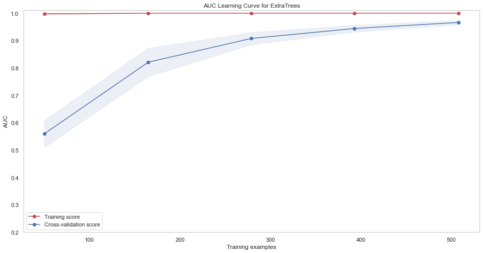

```python
# Cross validation with 5 iterations to get smoother mean test and train
# score curves, each time with 20% data randomly selected as a validation set.


title = 'AUC Learning Curve for ExtraTrees'                                      # fill this in
cv = ShuffleSplit(n_splits=5, test_size=0.2, random_state=42)
estimator = ExtraTreesClassifier(bootstrap=False, criterion="entropy", max_features=1.0, min_samples_leaf=3, min_samples_split=20, n_estimators=100)                                      # fill this in
plot_learning_curve(estimator, title, X_train, y_train, ylim=(0.2, 1.01), cv=cv, n_jobs=4)


plt.show()
```

# Feature Importance using Extra Trees Classifier

```python
X_train_cols = pd.DataFrame(X_train)
```

```python
collist = X_train_cols.columns.tolist()
cols_input = collist[0:440]
```

```python
feature_importances = pd.DataFrame(etc.feature_importances_,
                                   index = cols_input,
                                    columns=['importance']).sort_values('importance',
                                                                        ascending=False)
```

```python
feature_importances.head()
```

|  | importance |
| --- | --- |
| 38 | 0.060554 |
| 3 | 0.040355 |
| 6 | 0.037195 |
| 28 | 0.034283 |
| 22 | 0.033572 |

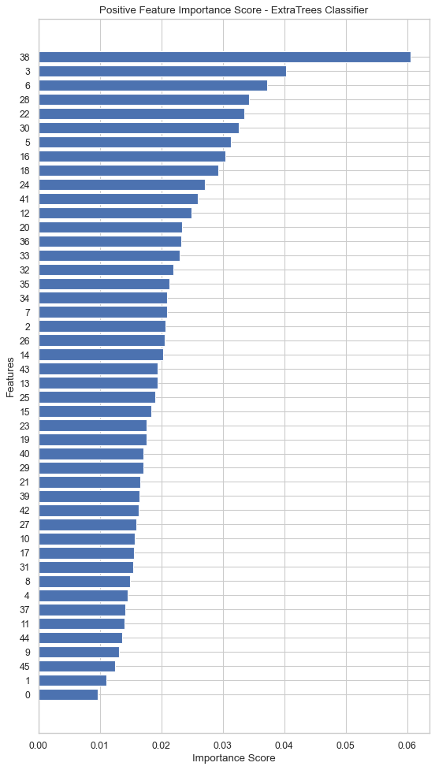

```python
pos_features = feature_importances.loc[feature_importances.importance > 0]

num = np.min([50, len(pos_features)])
ylocs = np.arange(num)
# get the feature importance for top num and sort in reverse order
values_to_plot = pos_features.iloc[:num].values.ravel()[::-1]
feature_labels = list(pos_features.iloc[:num].index)[::-1]

plt.figure(num=None, figsize=(8, 15), dpi=80, facecolor='w', edgecolor='k');
plt.barh(ylocs, values_to_plot, align = 'center')
plt.ylabel('Features')
plt.xlabel('Importance Score')
plt.title('Positive Feature Importance Score - ExtraTrees Classifier')
plt.yticks(ylocs, feature_labels)
plt.show()
```

# Feature Importance using Xgboost

```python
feature_importances = pd.DataFrame(xgbc.feature_importances_,
                                   index = cols_input,
                                    columns=['importance']).sort_values('importance',
                                                                        ascending=False)
```

```python
feature_importances.head()
```

|  | importance |
| --- | --- |
| 17 | 0.054865 |
| 40 | 0.051423 |
| 34 | 0.039849 |
| 6 | 0.039254 |
| 3 | 0.034328 |

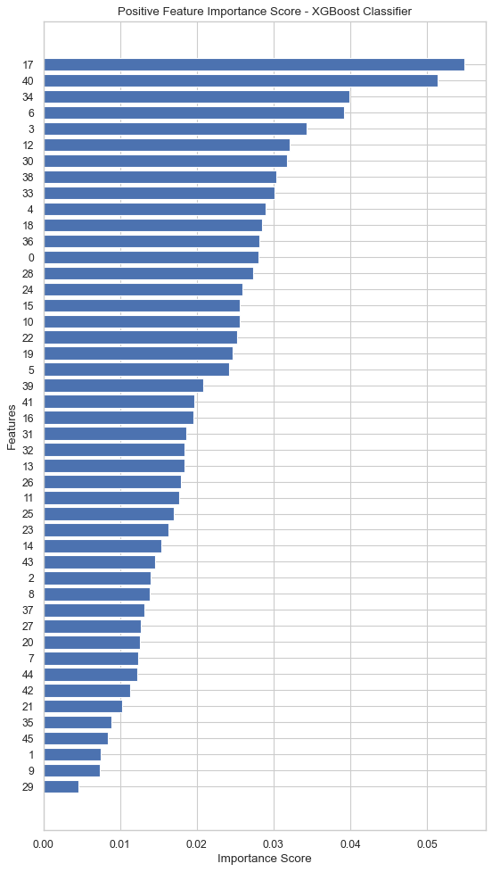

```python
pos_features = feature_importances.loc[feature_importances.importance > 0]

num = np.min([50, len(pos_features)])
ylocs = np.arange(num)
# get the feature importance for top num and sort in reverse order
values_to_plot = pos_features.iloc[:num].values.ravel()[::-1]
feature_labels = list(pos_features.iloc[:num].index)[::-1]

plt.figure(num=None, figsize=(8, 15), dpi=80, facecolor='w', edgecolor='k');
plt.barh(ylocs, values_to_plot, align = 'center')
plt.ylabel('Features')
plt.xlabel('Importance Score')
plt.title('Positive Feature Importance Score - XGBoost Classifier')
plt.yticks(ylocs, feature_labels)
plt.savefig('xgbc.png')
plt.show()
```

# Hyperparameter Tuning

TPOT is a python Automated Machine Learning tool that optimizes machine learning pipelines using genetic programming. It will automate the most tedious part of machine learning by intelligently exploring thousands of possible pipelines to find the best one for your data.

```python
from dask.distributed import Client
client = Client()
client
```

Client

- **Scheduler:** tcp://127.0.0.1:53751

- **Dashboard:** http://127.0.0.1:8787/status

Cluster

- **Workers:** 4

- **Cores:** 8

- **Memory:** 17.06 GB

```python
from tpot import TPOTClassifier
import numpy as np
tpot_config = {
    'xgboost.XGBClassifier': {
        'n_estimators': [100],
        'max_depth': range(1, 11),
        'learning_rate': [1e-3, 1e-2, 1e-1, 0.5, 1.],
        'subsample': np.arange(0.05, 1.01, 0.05),
        'min_child_weight': range(1, 21),
        'nthread': [1]
    },
    'sklearn.ensemble.ExtraTreesClassifier': {
        'n_estimators': [100],
        'criterion': ["gini", "entropy"],
        'max_features': np.arange(0.05, 1.01, 0.05),
        'min_samples_split': range(2, 21),
        'min_samples_leaf': range(1, 21),
        'bootstrap': [True, False]
    }

}
pipeline_optimizer = TPOTClassifier(verbosity=2, periodic_checkpoint_folder='tpot', generations=100,population_size=100, scoring='roc_auc', use_dask=True, config_dict=tpot_config, max_time_mins=20)
pipeline_optimizer.fit(X_train, y_train)
print(pipeline_optimizer.score(X_valid, y_valid))
pipeline_optimizer.export('tpot_exported_pipeline.py')
```

```
Generation 1 - Current best internal CV score: 0.9933531746031747
Generation 2 - Current best internal CV score: 0.9933531746031747
Generation 3 - Current best internal CV score: 0.9940724206349207
Generation 4 - Current best internal CV score: 0.9940724206349207
Generation 5 - Current best internal CV score: 0.9947172619047618
Generation 6 - Current best internal CV score: 0.9947172619047618
Generation 7 - Current best internal CV score: 0.9947172619047618
Generation 8 - Current best internal CV score: 0.9947172619047618
Generation 9 - Current best internal CV score: 0.9947172619047618
Generation 10 - Current best internal CV score: 0.9952132936507937
Generation 11 - Current best internal CV score: 0.9952132936507937
Generation 12 - Current best internal CV score: 0.9959325396825397

20.05 minutes have elapsed. TPOT will close down.
TPOT closed during evaluation in one generation.
WARNING: TPOT may not provide a good pipeline if TPOT is stopped/interrupted in a early generation.


TPOT closed prematurely. Will use the current best pipeline.

Best pipeline: ExtraTreesClassifier(CombineDFs(input_matrix, ExtraTreesClassifier(input_matrix, bootstrap=False, criterion=entropy, max_features=0.1, min_samples_leaf=1, min_samples_split=2, n_estimators=100)), bootstrap=False, criterion=entropy, max_features=0.6000000000000001, min_samples_leaf=14,…
1.0
```

I passed XGBoost and ExtraTrees classifiers to TPOT to run for 20minutes and the output is the best performing model between the two classifiers I chose. In the end, the ExtraTrees classifier was superior to XGBoost in AUC.

```python
import numpy as np
import pandas as pd
from sklearn.ensemble import ExtraTreesClassifier
from sklearn.model_selection import train_test_split
from sklearn.pipeline import make_pipeline, make_union
from tpot.builtins import StackingEstimator
from sklearn.preprocessing import FunctionTransformer
from copy import copy
```

```python
best_model = make_pipeline(
    make_union(
        FunctionTransformer(copy),
        make_union(
            make_union(
                FunctionTransformer(copy),
                make_union(
                    FunctionTransformer(copy),
                    make_union(
                        StackingEstimator(estimator=make_pipeline(
                            make_union(
                                FunctionTransformer(copy),
                                FunctionTransformer(copy)
                            ),
                            ExtraTreesClassifier(bootstrap=False, criterion="entropy", max_features=0.1,
                                                 min_samples_leaf=10, min_samples_split=10, n_estimators=100)
                        )),
                        FunctionTransformer(copy)
                    )
                )
            ),
            FunctionTransformer(copy)
        )
    ),
    ExtraTreesClassifier(bootstrap=False, criterion="entropy", max_features=0.6,
                         min_samples_leaf=14, min_samples_split=6, n_estimators=100)
)

best_model.fit(X_train, y_train)

y_train_preds = best_model.predict_proba(X_train)[:, 1]
y_valid_preds = best_model.predict_proba(X_valid)[:, 1]

print('ExtraTrees Classifier')
print('Training:')
xgbc_train_auc, xgbc_train_accuracy, xgbc_train_recall, xgbc_train_precision, xgbc_train_specificity = print_report(
    y_train, y_train_preds, thresh)
print('Validation:')
xgbc_valid_auc, xgbc_valid_accuracy, xgbc_valid_recall, xgbc_valid_precision, xgbc_valid_specificity = print_report(
    y_valid, y_valid_preds, thresh)
```

```
ExtraTrees Classifier
Training:
AUC:1.000
accuracy:0.997
recall:0.997
precision:0.997
specificity:0.997
prevalence:0.501

Validation:
AUC:0.985
accuracy:0.975
recall:0.962
precision:0.987
specificity:0.988
prevalence:0.497
```